# zad8

## First chart:

[figure not shown]

As I described in the last exercise, this chart is misleading because it compares single-year value to multi-year value. To improve this chart the last part 2017-2020 should be deleted.

**Code explanation:**

To explain the code I used {r,eval=FALSE}, so that the chunks illustrate the code without running it

Firstly I loaded needed library. :

```r
library(ggplot2)
```

Then I created data frame that contained year and spendings to use later for plot. I used factor to make sure years are treated as categorical values and are in the right order. I used levels so that years are sorted in the correct order:

```r
d <- data.frame(
  Rok = factor(c("2014", "2015", "2016", "2017", "2018", "2019"), levels = c("2014", "2015", "2016", "2017", "2018", "2019")),
  Wydatki = c(0.0, 0.0, 0.0, 0.4, 1.4, 3.1)
)
```

**Now for the plot:**

Firstly I defined axises (ggplot(d, aes(x = Rok, y = Wydatki). By using geom_col() I added bars and colored them:

```r
ggplot(d, aes(x = Rok, y = Wydatki)) +
  geom_col(fill = "deeppink3")
```

I used geom_text() to add value labels for each bar. I used paste0 command so that bar will show not only numbers but also “mld zł” behind them as it was in the orginal plot. I used vjust so that the text is above the bar. I added ylim(0,4), so that the whole text above the bar is fully visible:

```r
  geom_text(aes(label = paste0(Wydatki, " mld zł")), vjust = -0.5, size = 5,color="white")
```

I added ylim(0,4), so that the whole text above the bar is fully visible:

```r
  ylim(0,4)
```

I added title and described both axes:

```r
  labs(
    title = "Podwyżka wynagrodzeń nauczycieli finansowana z budżetu państwa",
    y = "Kwota (mld zł)",
    x = NULL
  )
```

I changed plot type to dark to mach the original version:

```r
  theme_dark()
```

**R script:**

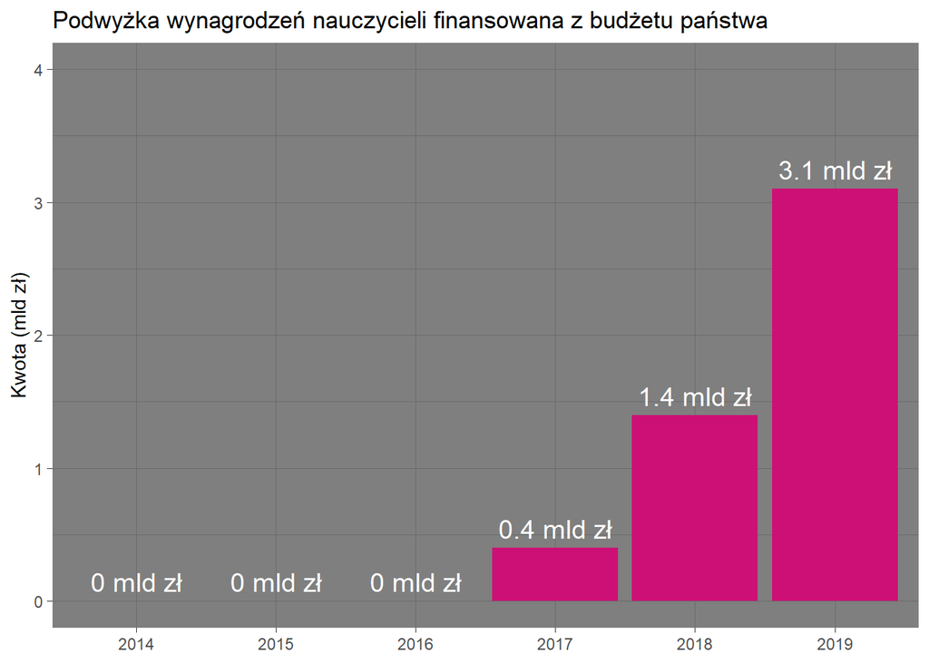

```r
library(ggplot2)

d <- data.frame(
  Rok = factor(c("2014", "2015", "2016", "2017", "2018", "2019"), levels = c("2014", "2015", "2016", "2017", "2018", "2019")),
  Wydatki = c(0.0, 0.0, 0.0, 0.4, 1.4, 3.1)
)

ggplot(d, aes(x = Rok, y = Wydatki)) +
  geom_col(fill = "deeppink3") +
  geom_text(aes(label = paste0(Wydatki, " mld zł")), vjust = -0.5, size = 5,color="white") +
  ylim(0,4)+
  labs(
    title = "Podwyżka wynagrodzeń nauczycieli finansowana z budżetu państwa",
    y = "Kwota (mld zł)",
    x = NULL
  )+
  theme_dark()
```

## Second chart:

[figure not shown]

Main problem with this one was that y-axis did not start with zero, so the bar lenghts were misleading for the viewer and also this plot is not aesteticly pleasing. I moved the y-axis to start in zero and made the plot more approachable:

Firstly I created data frame to use later for the plot:

```r
dane <- data.frame(
  Stacja = c("TVP2", "TVP1", "TVN", "Polsat"),
  Udział = c(7.85, 7.76, 7.32, 7.26)
)
```

**Plot:**

I named axes, added bars and colored them:

```r
ggplot(dane, aes(x = Stacja, y = Udział)) +
  geom_col(fill = "seagreen4")
```

I used geom_text to add text above each bar:

```r
  geom_text(aes(label = paste0(Udział, "%")), vjust = -0.5, color = "black")
```

The “scale_y_continous(limits=c(0,8))” sets y-axis scale from 0 to 8. I used ylim so that the text above the bar would be fully visible:

```r
  scale_y_continuous(limits = c(0, 8))
```

I used ylim so that the text above the bar would be fully visible:

```r
  ylim(0,9)
```

I added title and labeled each axises:

```r
  labs(
    title = "Udziały 4 głównych stacji w marcu 2023",
    y = "Udział w rynku (%)",
    x = NULL
  )
```

I changed the plot theme:

```r
  theme_minimal()
```

**Whole script:**

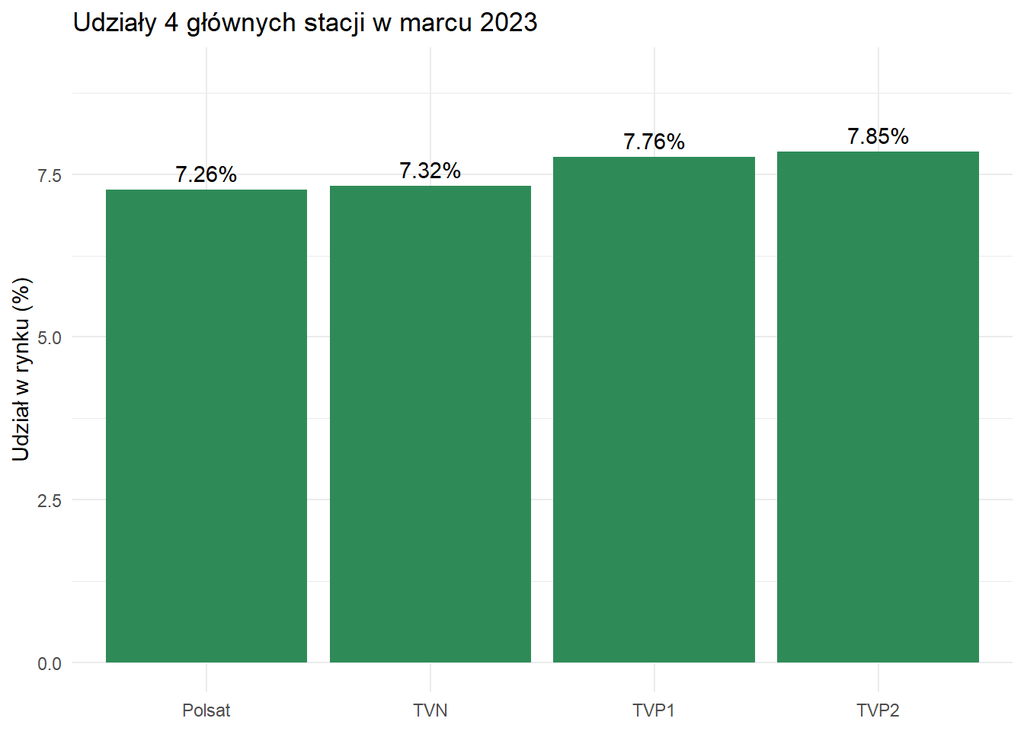

```r
dane <- data.frame(
  Stacja = c("TVP2", "TVP1", "TVN", "Polsat"),
  Udział = c(7.85, 7.76, 7.32, 7.26)
)

ggplot(dane, aes(x = Stacja, y = Udział)) +
  geom_col(fill = "seagreen4") +
  geom_text(aes(label = paste0(Udział, "%")), vjust = -0.5, color = "black") +
  scale_y_continuous(limits = c(0, 8)) +
  ylim(0,9)+
  labs(
    title = "Udziały 4 głównych stacji w marcu 2023",
    y = "Udział w rynku (%)",
    x = NULL
  ) +
  theme_minimal()
```